## [CHECK-IN : Post Brain-Exam Survey!](https://docs.google.com/forms/d/e/1FAIpQLSeQnoTd_QK7Lp91-T98IyCR0p0gqWNJiAPUAcEFmpbE7Qv0qg/viewform?usp=header)

[figure not shown]

# PART 1 : Prediction

## Measures are a Prediction

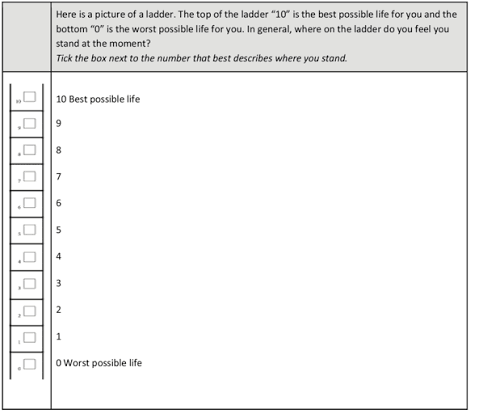

- Could you place yourself on this ladder?
- Does this seem like a **valid** way to measure happiness?
- What benefits / problems are there of this approach?
- What questions do you have?

## The Mean as *Prediction* (with Error)

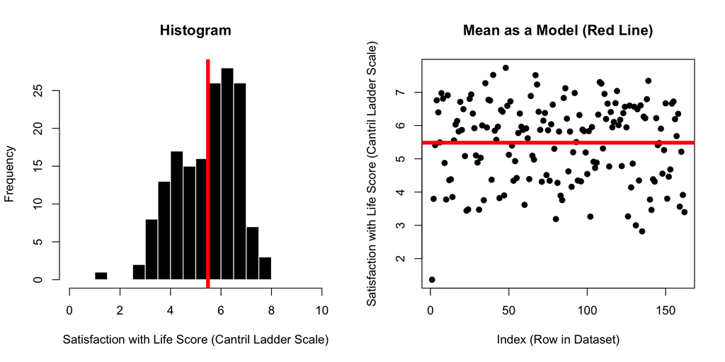

### RECAP : The Mean as Prediction?

$\huge y_i = \hat{Y} + \epsilon_i$

$\Large y_i$ = the DV = the individual’s actual score we are trying to predict.

- `on the graph: each individual dot`

$\Large \hat{Y}$ = our prediction (the mean).

- `on the graph: the solid red line`

$\Large \epsilon$ = residual error = difference between predicted and actual values of y

- `on the graph: the distance between each dot and the line.`

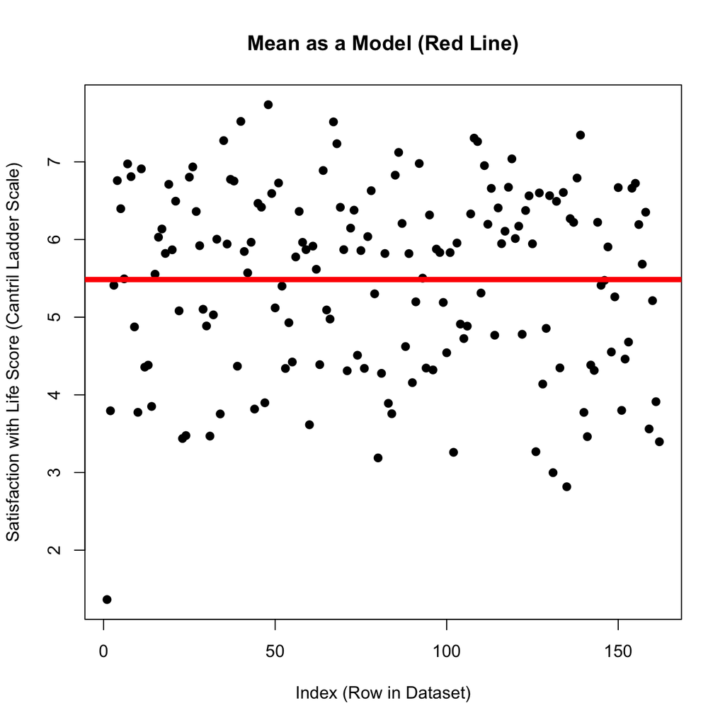

### RECAP : The Mean as Prediction With Error

$\huge \epsilon_i = y_i - \hat{Y}$

Error = actual score - prediction (the mean)

```r
residual <- d$SWLS_24 - mean(d$SWLS_24, na.rm = T)
SST <- sum(residual^2, na.rm = T)
SST
```

```
[1] 233.827
```

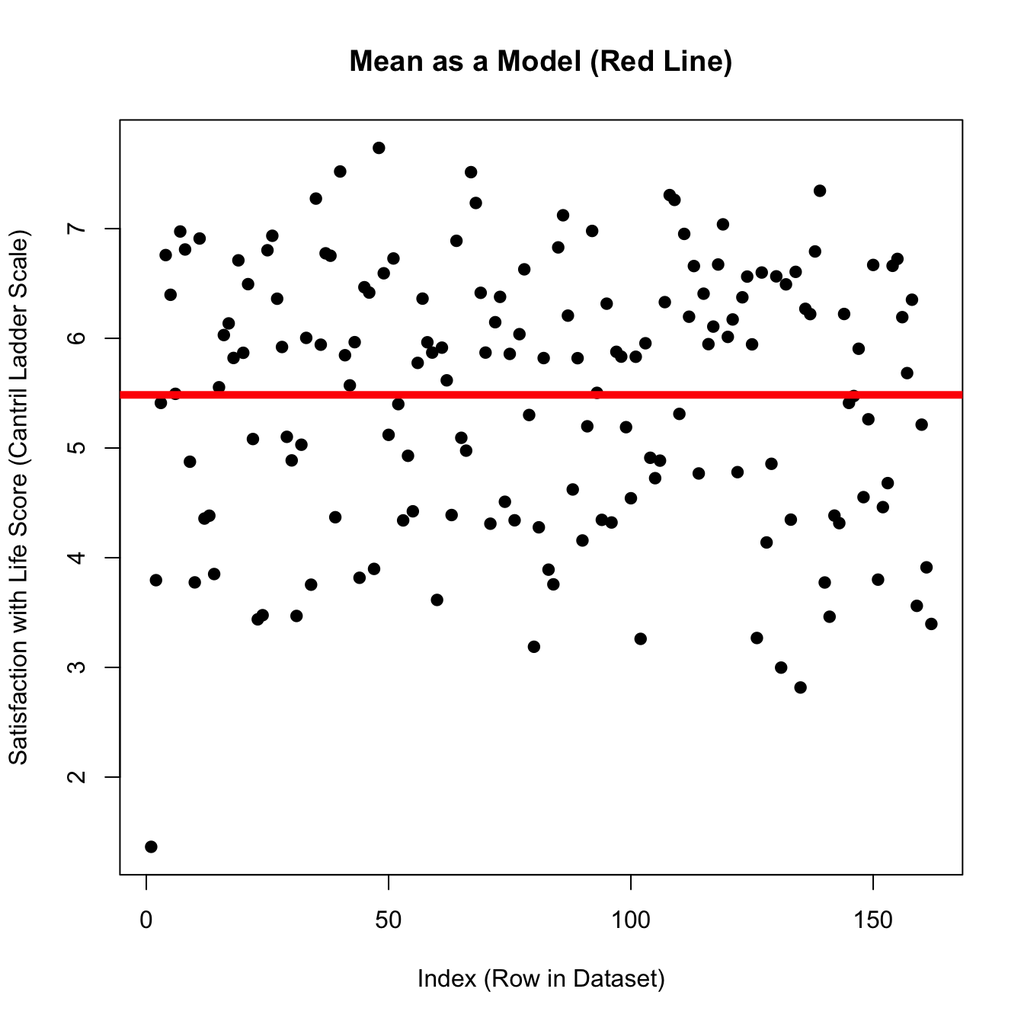

### KEY IDEA : The mean is an okay starting place for our predictions, but we can try to do better!

| **the mean** | **the linear model ™ ©** |
| --- | --- |

### DISCUSS : Making Predictions

- **THINK ABOUT A LINEAR MODEL :** how do you think the variables (below) would help (or not help) us predict the happiness of a country in 2024? Why / why not???
- **THINK ABOUT SOURCES OF DATA**. What other variables do you think would be important to include in this dataset?

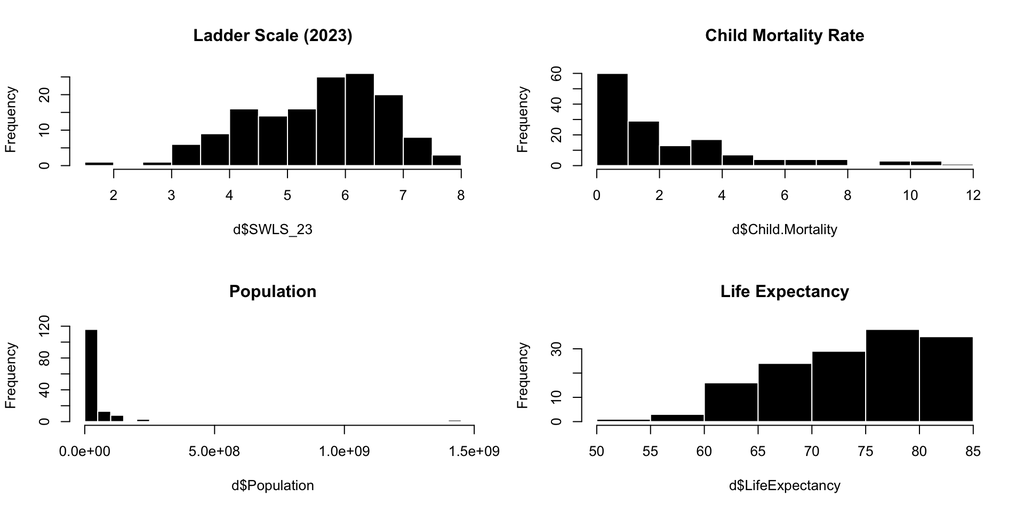

### TIME TO PLAY : WHERE’S THE LINE

- Where the Line?
- There the Line!

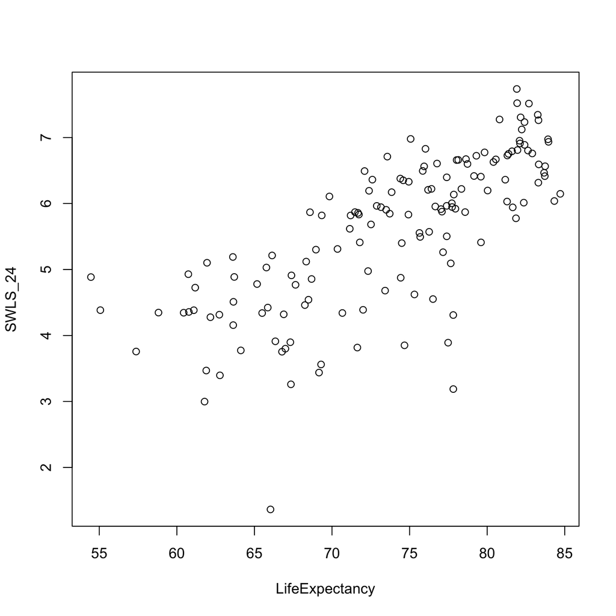

### What’s Going On : It’s a Line

$\Huge y_i = a + b_1 * X_i + \epsilon_i$

```
   (Intercept) LifeExpectancy
         -3.14           0.12
```

```
   (Intercept) LifeExpectancy
    -3.1408300      0.1181053
```

$\Large y_i$ = the DV = each actual score on the DV.

- `on the graph:** each dot on the y-axis`

$\Large a$ = the intercept = starting place for our prediction (“the predicted value of y when all x values are zero”.)

- `on the graph:** the value of the line at X = 0`

$\Large X_i$ = the IV = the actual score on the IV.

- `on the graph: the value of each dot on the x-axis`

$\Large b_1$ = the slope = an adjustment to our prediction of y based changes in x

- `on the graph: how much the line increases in y value when x-values increase by 1 unit.`

$\Large \epsilon_i$ = residual error = the distance between actual y and predicted y

- `on the graph: the distance between each individual data point and the line.`

### What’s Going On : R Code to Draw The Line

$\Huge y_i = a + b_1 * X_i + \epsilon_i$

```
   (Intercept) LifeExpectancy
         -3.14           0.12
```

```r
mod <- lm(SWLS_24 ~ LifeExpectancy, data = d)
plot(SWLS_24 ~ LifeExpectancy, data = d)
abline(mod, lwd = 5, col = 'red')
```

[output not shown]

- **plot(DV ~ IV, data = d) :** draws the scatterplot based on the relationship between the DV and IV
- **mod <- lm(DV ~ IV, data = d) :** defines a linear model based on the relationship between the DV and IV and saves this as an object called mod
- **abline(mod) :** draws a line based on the a value (intercept) and b value (slope) of mod
- **coef(mod) :** shows the values of the coefficients in the model (a and b)

## The Linear Model : Quantifying Error

- Which model has more error?
- How big is the difference in error?
- Is this a Big or Small Difference?

```r
SWLS24 <- mod$model$SWLS_24 # using data that also have life expectancy
residual <- SWLS24 - mean(SWLS24) # error
SST <- sum(residual^2, na.rm = T) # sum of squared errors
SST # total sum of squared errors
```

```
[1] 195.867
```

```r
SSM <- sum(mod$residuals^2) # R saves the residuals for you
SSM # hooray!
```

```
[1] 89.63457
```

Some math helps us evaluate.

```r
SST - SSM # the total difference
```

```
[1] 106.2324
```

```r
(SST - SSM)/SST # the relative difference
```

```
[1] 0.5423702
```

```r
summary(mod)$r.squared # R^2
```

```
[1] 0.5423702
```

## BREAK TIME : MEET BACK AT 4:15

[figure not shown]

# PART 2 : Milestone 2, Part B

### [Milestone #2 (Measures)](https://docs.google.com/document/d/1DxiIxm_sRtm8t5FEOWhOJluJOo6ZPUI_eZTS13K4CxA/edit?tab=t.0#bookmark=id.8eg84yu09e7c)

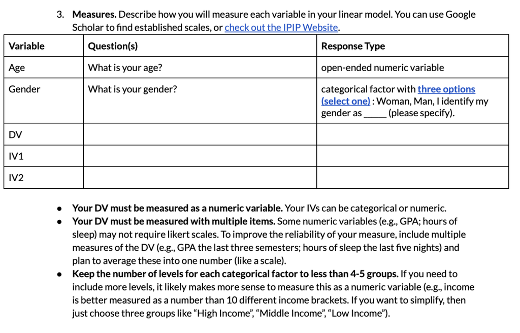

### The Likert Scale

#### Example : [Satisfaction With Life Scale](https://ppc.sas.upenn.edu/resources/questionnaires-researchers/satisfaction-life-scale)

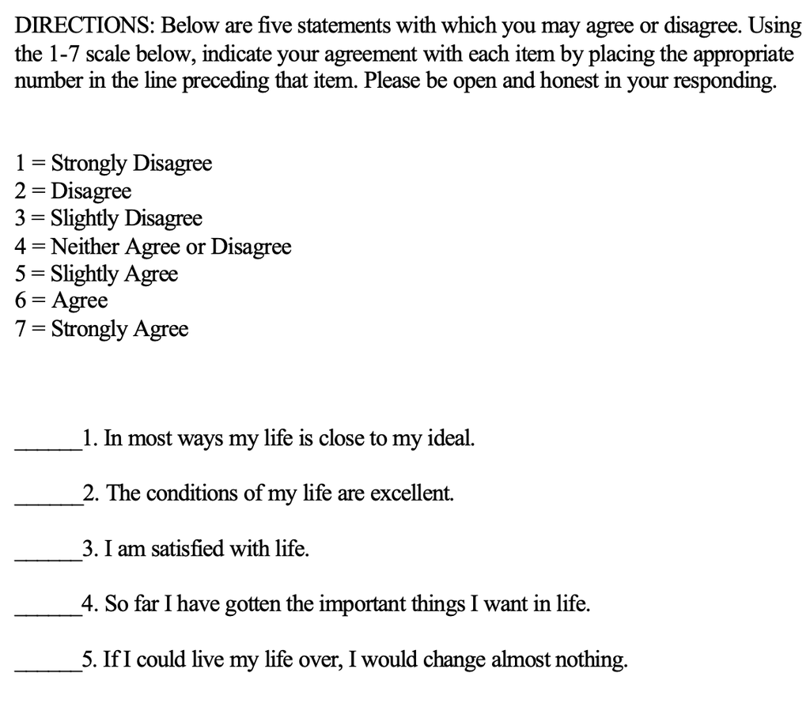

- scale : The variable that you want to measure as a continuous variable.
- items : The specific question(s) in the scale. Each item measures some aspect of the variable the researcher is interested in.
  - positively keyed items : An item that measures the high end of the scale, where answering “yes” to the question means you are high on this variable.
  - negatively keyed items : An item that measures the low end of the scale, where answering “yes” to the question means you are low on the variable.
- response scale : How people answer the scale items.

### [Some Student Examples : Professor Office Hours](https://docs.google.com/document/d/1mzCALLQ2aWshxAbqXBbvgOn_QSEZbA6WGomMisiGSDw/edit?usp=sharing)

## PART 3 : Reliability and Validity

### **Relevance to Real-Life.**

How would you evaluate the reliability and validity of the STEP COUNTER on your phone???

| **Term** | **Way of Testing** |
| --- | --- |
| **face :** does our measure or result look like what it should look like? |  |
| **convergent :** is our measure similar to related concepts? |  |
| **discriminant :** is our measure different from unrelated concepts? |  |
| **test-retest :** do we get the same result if we take multiple measures? |  |
| **interrater reliability :** would another observer make the same measurements? |  |
| **inter-item reliability :** would one item in the likert scale be related to others? |  |

### Relevance to Psychological Science

#### Reliability in Neuroscience

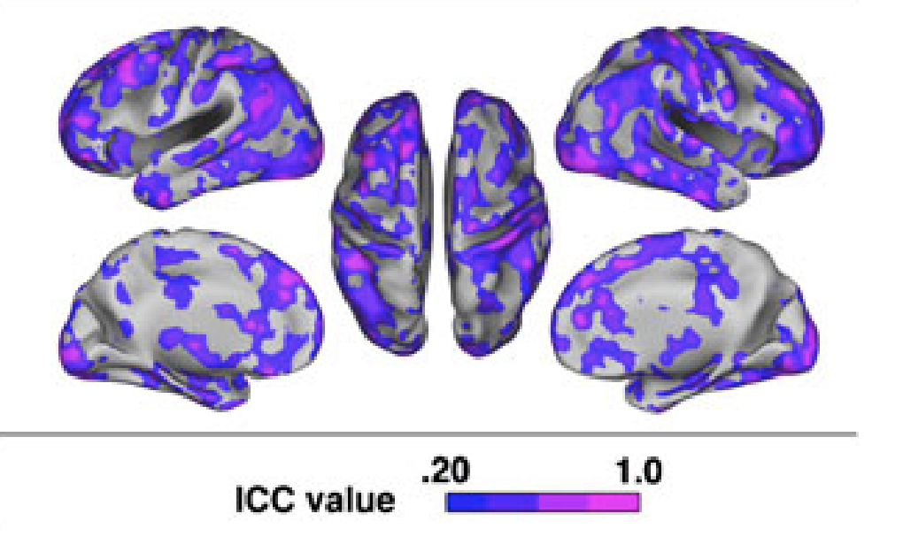

Brandt, D. J., Sommer, J., Krach, S., Bedenbender, J., Kircher, T., Paulus, F. M., & Jansen, A. (2013). Test-retest reliability of fMRI brain activity during memory encoding. Frontiers in psychiatry, 4, 163. [Link to Full Article](https://www.frontiersin.org/articles/10.3389/fpsyt.2013.00163/full)

### Relevance to Psychological Science

#### Validity in Neuroscience

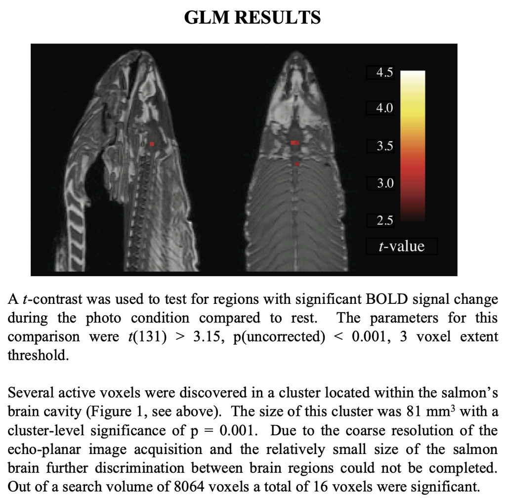

Bennett, C. M., Miller, M. B., & Wolford, G. L. (2009). Neural correlates of interspecies perspective taking in the post-mortem Atlantic Salmon: an argument for multiple comparisons correction. Neuroimage, 47(Suppl 1), S125. [Link to Full Article](http://prefrontal.org/files/posters/Bennett-Salmon-2009.pdf)